# Logistic Regression to Predict Insurance Claims

Cody Clayton

Date: September 17, 2017

# Objective

The objective of this project is to identify auto insurance buyers who have a higher risk of submitting a claim within the first year of a policy based on the information available at the time of purchase. This information can then be used as a tool when determining the appropriate premium to charge the buyer in order to lower cost for the company.

# Data Exploration and Insights

To create an effective model we must first ensure that the policy characteristics being utilized are accurate, available at that time of purchase and predictive of a claim submission. To ensure this:

1. Only the data available before the policy is taken out can be utilized. Therefore, the information regarding the **number of claims submitted** and the **amount of the claims** will not be considered.
2. Data that has no predictive power can be removed. Since the **X_OBSTAT_** feature has the same value for all policies, it can be ignored.
3. Data that is inaccurate should be transformed or removed. 53 policies have a vehicle value of $0.00 which is incorrect. Furthermore, the exposure value for these 53 policies also appears to be inflated compared to the population. For these reasons and because this only represent a very small portion of the population, they will be removed.

```
## Percent of $0.00 vehicle value polices with exposure > 0.99: 43.40%
```

```
## Percent of population with exposure > 0.99: 2.44%
```

It is also important to examine the features to determine if there are any obvious correlations to a claim submission. If we break down the proportion of policies that sumbit a claim based on the claim characteristics we are able to see a few obvious patterns.

1. There is a clear relationship between the age of the driver and the submission of a claim. As age increases the proportion of vehicles that submit claims decreases.

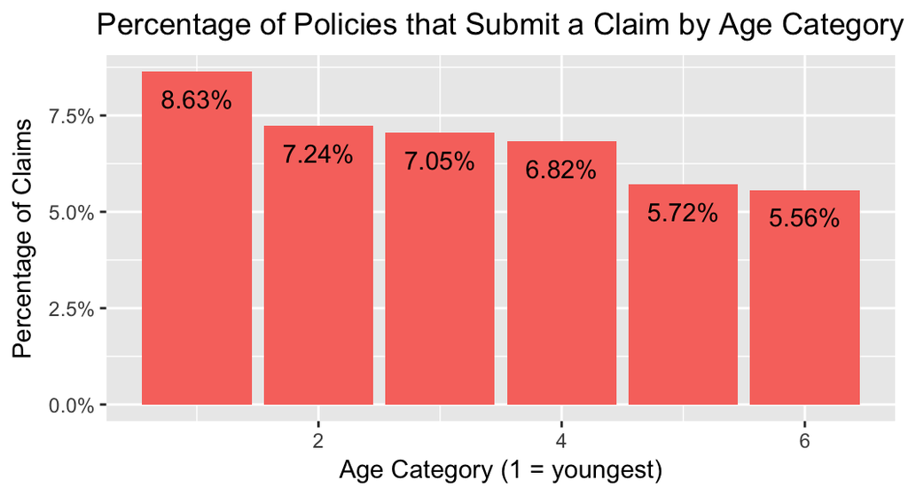

2. Higher exposure also could be a good predictor as policies with high exposure appear to be more likely to submit a claim.

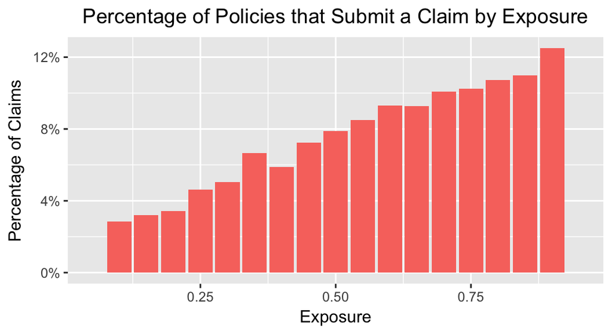

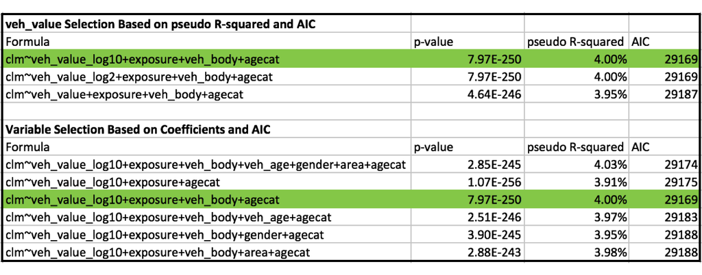